# Figures: 2008-2015 totals by county

# P1: Annual Blue WF, CWR, and PPT, county-wise

It appears that there are a fair number of counties that are significantly greater than the median $WF_{blue}$. The second plot identifies some of these counties by labling the top 99th percentile counties by $WF_{blue}$. Note that we’re tagging entries in the top 99% *per year*, not the top 99% overall.

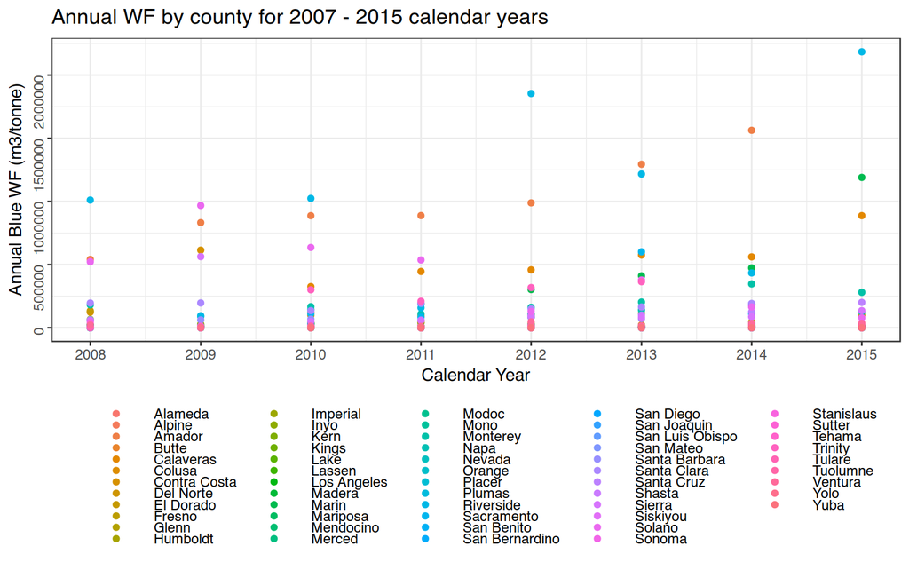

```r
# local({
  # wfb <-
  wf.master.bycounty.wyear %>%
    ggplot() +
    geom_point(mapping = aes(x = Year, y = wf.b, color = County)) +
    scale_x_date(date_breaks = "1 years", date_labels = "%Y") +
    labs(title = "Annual WF by county for 2007 - 2015 calendar years",
         x = "Calendar Year", y = "Annual Blue WF (m3/tonne)",
         color = "County Name") +
    theme(legend.position = "bottom", legend.spacing.x=unit(1,"line"),
          legend.title = element_blank(), legend.key.size = unit(.5, 'lines'),
          legend.direction = 'horizontal', legend.key.width=unit(3,"line")) +
    theme(axis.text.y = element_text(angle = 90))
```

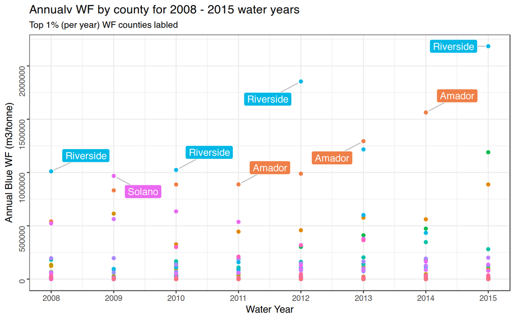

```r
  # wfb.labeled <
  wf.master.bycounty.wyear %>%
    group_by(Year) %>%
    mutate(percentile = percent_rank(wf.b)) %>%
    ggplot() +
    geom_point(mapping = aes(x = Year, y = wf.b, color = County)) +
    geom_label_repel(mapping = aes(x = Year, y = wf.b,
                                   label = ifelse(percentile > 0.99, County, NA),
                                   fill = County),
                     color = "white", segment.color = 'grey', box.padding = unit(0.35, "lines"),
                     point.padding = unit(0.5, "lines"), na.rm = TRUE) +
    scale_x_date(date_breaks = "1 years", date_labels = "%Y") +
    labs(title = "Annualv WF by county for 2008 - 2015 water years",
         subtitle = "Top 1% (per year) WF counties labled",
         x = "Water Year", y = "Annual Blue WF (m3/tonne)",
         color = "County Name") +
    guides(fill = "none", color = "none") +
    theme(axis.text.y = element_text(angle = 90))
```

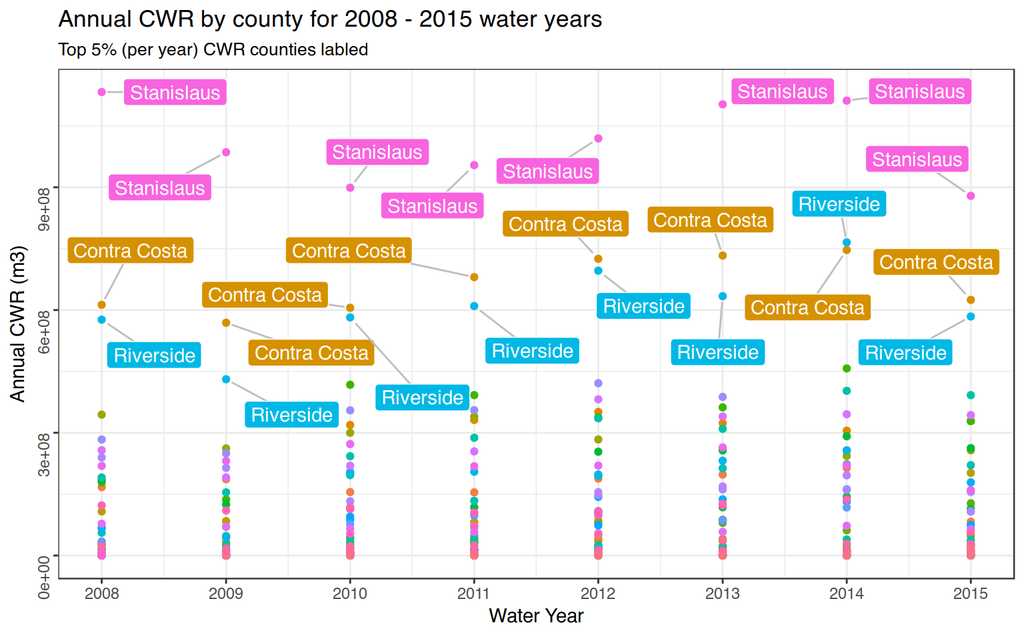

```r
  # cwr.labeled <
  wf.master.bycounty.wyear %>%
    group_by(Year) %>%
    mutate(percentile = percent_rank(cwr)) %>%
    ggplot() +
    geom_point(mapping = aes(x = Year, y = cwr, color = County)) +
    geom_label_repel(mapping = aes(x = Year, y = cwr,
                                   label = ifelse(percentile > 0.95, County, NA),
                                   fill = County),
                     color = "white", segment.color = 'grey', box.padding = unit(0.35, "lines"),
                     point.padding = unit(0.5, "lines"), na.rm = TRUE) +
    scale_x_date(date_breaks = "1 years", date_labels = "%Y") +
    labs(title = "Annual CWR by county for 2008 - 2015 water years",
         subtitle = "Top 5% (per year) CWR counties labled",
         x = "Water Year", y = "Annual CWR (m3)",
         color = "County Name") +
    guides(fill = "none", color = "none") +
    theme(axis.text.y = element_text(angle = 90))
```

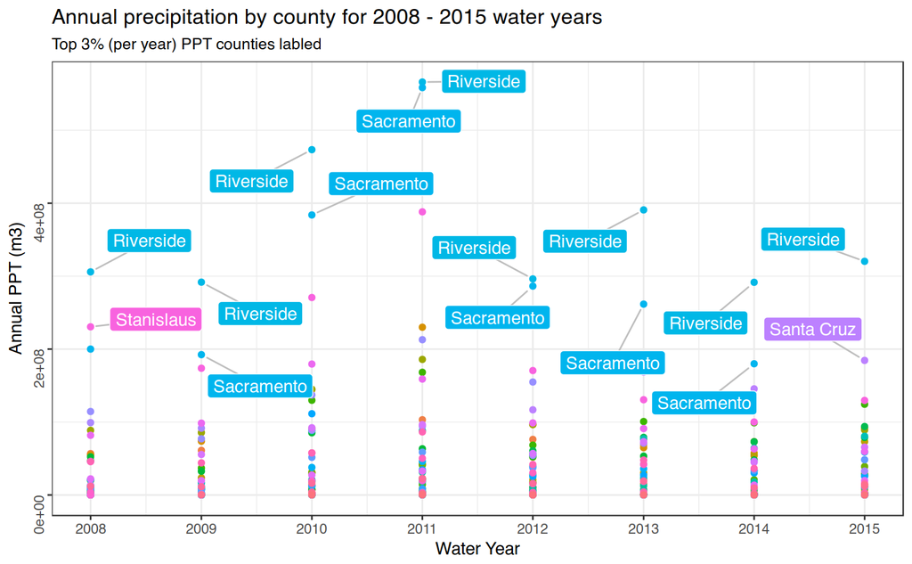

```r
  # ppt.labeled <
  wf.master.bycounty.wyear %>%
    group_by(Year) %>%
    mutate(percentile = percent_rank(ppt)) %>%
    ggplot() +
    geom_point(mapping = aes(x = Year, y = ppt, color = County)) +
    geom_label_repel(mapping = aes(x = Year, y = ppt,
                                   label = ifelse(percentile > 0.97, County, NA),
                                   fill = County),
                     color = "white", segment.color = 'grey', box.padding = unit(0.35, "lines"),
                     point.padding = unit(0.5, "lines"), na.rm = TRUE) +
    scale_x_date(date_breaks = "1 years", date_labels = "%Y") +
    labs(title = "Annual precipitation by county for 2008 - 2015 water years",
         subtitle = "Top 3% (per year) PPT counties labled",
         x = "Water Year", y = "Annual PPT (m3)",
         color = "County Name") +
    guides(fill = "none", color = "none") +
    theme(axis.text.y = element_text(angle = 90))
```

```r
  #plot_grid(arrangeGrob(wfb_vs_wfg, etb_vs_etg, ncol=1), nrow = 1)
# })
```

# P2: Annual Blue WF, CWR, and PPT, county-wise w/ Hydrologic Regions

We can also group counties by a classification based on location. Here, we are using regional classifications that align with the major drainage basins of California. These `Hydrologic Regions` correspond to drainage basins that are used for a variety of planning purposes and DWR programs, including the CA Water plan.

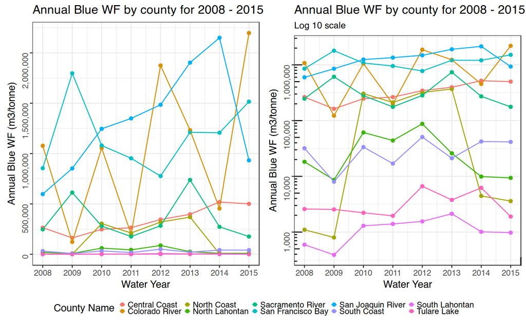

```r
local({

wfb_icc <- wf.master.byHR.wyear %>%
  ggplot() +
  geom_point(mapping = aes(x = Year, y = wf.b, color = HR_NAME)) +
  geom_line(mapping = aes(x = Year, y = wf.b, color = HR_NAME)) +
  scale_x_date(date_breaks = "1 years", date_labels = "%Y") +
  scale_y_continuous(labels = scales::comma) +
  labs(title = "Annual Blue WF by county for 2008 - 2015 water years",
       x = "Water Year", y = "Annual Blue WF (m3/tonne)",
       color = "County Name") +
  theme(axis.text.y = element_text(angle = 90), legend.position="none") +
   theme(legend.position = "none")

wfb_icc_log <- wf.master.byHR.wyear %>%
  ggplot() +
  geom_point(mapping = aes(x = Year, y = wf.b, color = HR_NAME)) +
  geom_line(mapping = aes(x = Year, y = wf.b, color = HR_NAME)) +
  scale_x_date(date_breaks = "1 years", date_labels = "%Y") +
  scale_y_continuous(trans = "log10", labels = scales::comma,
                     breaks = scales::trans_breaks("log10", function(x) 10^x)) +
  annotation_logticks() +
  labs(title = "Annual Blue WF by county for 2008 - 2015 water years",
       subtitle = ("Log 10 scale"),
       x = "Water Year", y = "Annual Blue WF (m3/tonne)",
       color = "County Name") +
  theme(axis.text.y = element_text(angle = 90), legend.position="none") +
  guides(line = "none") +
  theme(legend.position = "none")

  l1 <- get_legend(wfb_icc + guides(color = guide_legend()) +
                   theme(legend.position="bottom", legend.spacing.x=unit(1,"line"),
                         legend.key.size = unit(.5, 'lines')))

  plot_grid(arrangeGrob(wfb_icc, wfb_icc_log, ncol=2), l1, ncol = 1, rel_heights = c(1, .1))
})
```

# P2.5: CWR and PPT w/ Hydrologic Regions

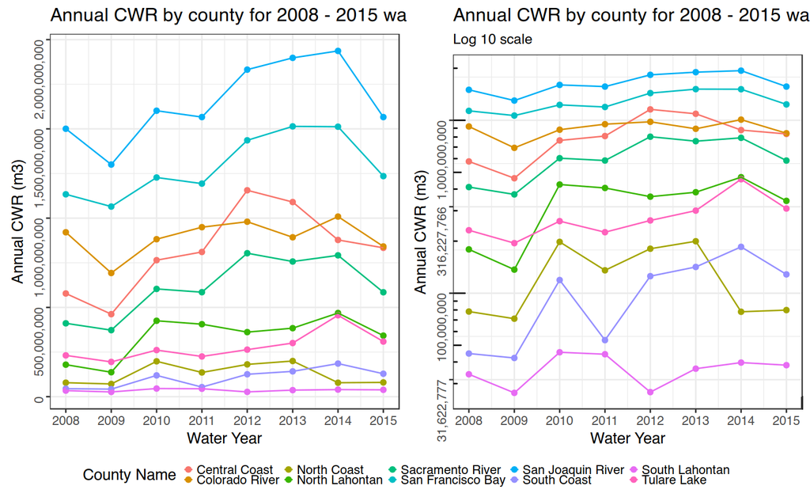

```r
local({

cwr_icc <- wf.master.byHR.wyear %>%
  ggplot() +
  geom_point(mapping = aes(x = Year, y = cwr, color = HR_NAME)) +
  geom_line(mapping = aes(x = Year, y = cwr, color = HR_NAME)) +
  scale_x_date(date_breaks = "1 years", date_labels = "%Y") +
  scale_y_continuous(labels = scales::comma) +
  labs(title = "Annual CWR by county for 2008 - 2015 water years",
       x = "Water Year", y = "Annual CWR (m3)",
       color = "County Name") +
  theme(axis.text.y = element_text(angle = 90), legend.position="none") +
   theme(legend.position = "none")

cwr_icc_log <- wf.master.byHR.wyear %>%
  ggplot() +
  geom_point(mapping = aes(x = Year, y = cwr, color = HR_NAME)) +
  geom_line(mapping = aes(x = Year, y = cwr, color = HR_NAME)) +
  scale_x_date(date_breaks = "1 years", date_labels = "%Y") +
  scale_y_continuous(trans = "log10", labels = scales::comma,
                     breaks = scales::trans_breaks("log10", function(x) 10^x)) +
  annotation_logticks() +
  labs(title = "Annual CWR by county for 2008 - 2015 water years",
       subtitle = ("Log 10 scale"),
       x = "Water Year", y = "Annual CWR (m3)",
       color = "County Name") +
  theme(axis.text.y = element_text(angle = 90), legend.position="none") +
  guides(line = "none") +
  theme(legend.position = "none")

  l1 <- get_legend(cwr_icc + guides(color = guide_legend()) +
                   theme(legend.position="bottom", legend.spacing.x=unit(1,"line"),
                         legend.key.size = unit(.5, 'lines')))

  plot_grid(arrangeGrob(cwr_icc, cwr_icc_log, ncol=2), l1, ncol = 1, rel_heights = c(1, .1))
})
```

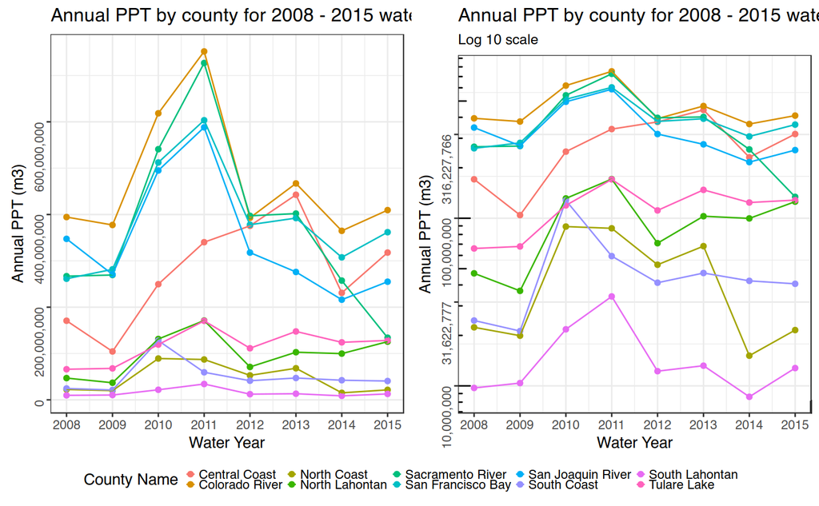

```r
local({

ppt_icc <- wf.master.byHR.wyear %>%
  ggplot() +
  geom_point(mapping = aes(x = Year, y = ppt, color = HR_NAME)) +
  geom_line(mapping = aes(x = Year, y = ppt, color = HR_NAME)) +
  scale_x_date(date_breaks = "1 years", date_labels = "%Y") +
  scale_y_continuous(labels = scales::comma) +
  labs(title = "Annual PPT by county for 2008 - 2015 water years",
       x = "Water Year", y = "Annual PPT (m3)",
       color = "County Name") +
  theme(axis.text.y = element_text(angle = 90), legend.position="none") +
   theme(legend.position = "none")

ppt_icc_log <- wf.master.byHR.wyear %>%
  ggplot() +
  geom_point(mapping = aes(x = Year, y = ppt, color = HR_NAME)) +
  geom_line(mapping = aes(x = Year, y = ppt, color = HR_NAME)) +
  scale_x_date(date_breaks = "1 years", date_labels = "%Y") +
  scale_y_continuous(trans = "log10", labels = scales::comma,
                     breaks = scales::trans_breaks("log10", function(x) 10^x)) +
  annotation_logticks() +
  labs(title = "Annual PPT by county for 2008 - 2015 water years",
       subtitle = ("Log 10 scale"),
       x = "Water Year", y = "Annual PPT (m3)",
       color = "County Name") +
  theme(axis.text.y = element_text(angle = 90), legend.position="none") +
  guides(line = "none") +
  theme(legend.position = "none")

  l1 <- get_legend(ppt_icc + guides(color = guide_legend()) +
                   theme(legend.position="bottom", legend.spacing.x=unit(1,"line"),
                         legend.key.size = unit(.5, 'lines')))

  plot_grid(arrangeGrob(ppt_icc, ppt_icc_log, ncol=2), l1, ncol = 1, rel_heights = c(1, .1))
})
```

# P3: Annual Blue WF, CWR by Hydrologic Regions

We can also separate counties by their hydrologic region, to view similar graphs on their own scale.

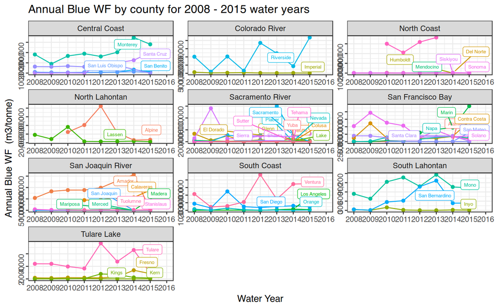

```r
wf.master.bycounty.wyear %>%
  ggplot() +
  geom_point(mapping = aes(x = Year, y = wf.b, color = County)) +
  facet_wrap(~HR_NAME, ncol = 3, scales = "free") +
  geom_line(mapping = aes(x = Year, y = wf.b, color = County)) +
  geom_label_repel(mapping = aes(x = Year, y = wf.b,
                                 label = ifelse(Year == max(wf.master.bycounty.wyear[["Year"]])%m-% months(12),County,NA),
                                 color = County),
                   box.padding = unit(0.25, "lines"),
                   point.padding = unit(0.4, "lines"), nudge_x = 35, na.rm = TRUE, size = 2) +
  scale_x_date(date_breaks = "1 years", date_labels = "%Y") +
  scale_y_continuous(labels = scales::comma) +
  expand_limits(x = as.Date("2016-01-01")) +
  labs(title = "Annual Blue WF by county for 2008 - 2015 water years",
      x = "Water Year", y = "Annual Blue WF  (m3/tonne)",
      color = "County Name") +
  theme(axis.text.y = element_text(angle = 90), legend.position="none") +
  guides(fill = "none")
```

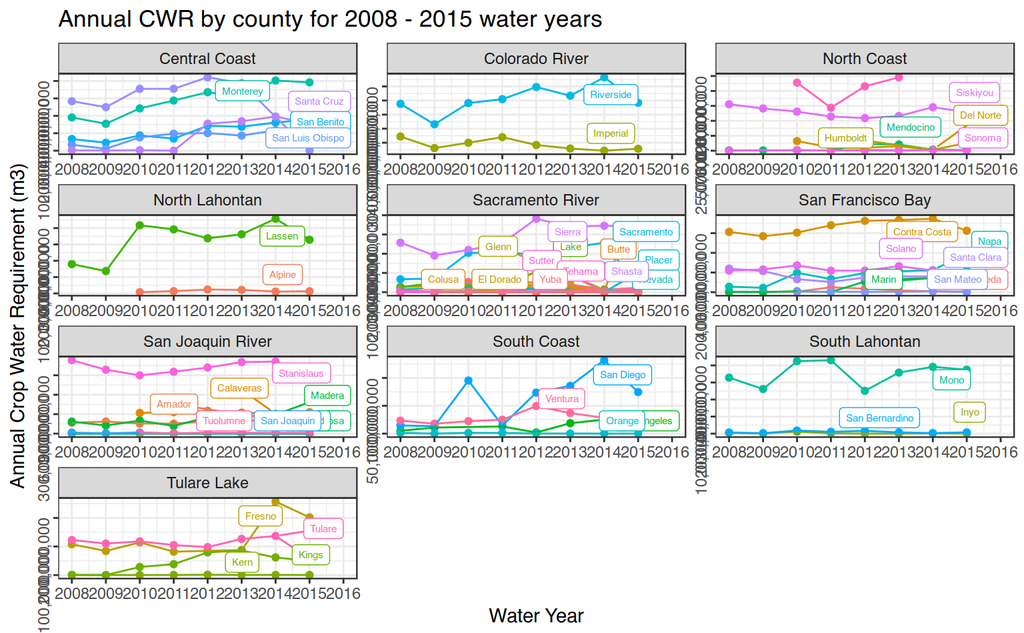

```r
wf.master.bycounty.wyear %>%
  ggplot() +
  geom_point(mapping = aes(x = Year, y = cwr, color = County)) +
  facet_wrap(~HR_NAME, ncol = 3, scales = "free") +
  geom_line(mapping = aes(x = Year, y = cwr, color = County)) +
  geom_label_repel(mapping = aes(x = Year, y = cwr,
                                 label = ifelse(Year == max(wf.master.bycounty.wyear[["Year"]])%m-% months(12),County,NA),
                                 color = County),
                   box.padding = unit(0.25, "lines"),
                   point.padding = unit(0.4, "lines"), nudge_x = 35, na.rm = TRUE, size = 2) +
  scale_x_date(date_breaks = "1 years", date_labels = "%Y") +
  scale_y_continuous(labels = scales::comma) +
  expand_limits(x = as.Date("2016-01-01")) +
  labs(title = "Annual CWR by county for 2008 - 2015 water years",
      x = "Water Year", y = "Annual Crop Water Requirement (m3)",
      color = "County Name") +
  theme(axis.text.y = element_text(angle = 90), legend.position="none") +
  guides(fill = "none")
```